# PCA on Faces Dataset

In this assignment, we will use PCA for dimensionality reduction on the MIT Face Recognition Dataset (https://courses.media.mit.edu/2004fall/mas622j/04.projects/faces/). The following code collects images from rawdata and stores them in a 128x128x(number of images) tensor - image_collection.

See the following link for how to use PCA in scikit-learn: https://scikit-learn.org/stable/modules/generated/sklearn.decomposition.PCA.html

```python
import os
import skimage
import numpy as np
import matplotlib.pyplot as plt
import skimage.measure

IMAGE_SIZE = 128
directory  = os.fsencode('rawdata/')
num_files  = len([file for file in os.listdir(directory) \
                  if os.path.isfile(os.path.join(directory, file))])
image_collection = np.zeros((IMAGE_SIZE,IMAGE_SIZE,num_files))
count = 0

for file in os.listdir(directory):
    filename   = os.fsdecode(file)
    temp_image = np.fromfile('rawdata/'+filename, dtype='uint8', sep="")
    ratio      = temp_image.shape[0]/(IMAGE_SIZE*IMAGE_SIZE)
    if ratio > 1:
        temp_image = np.reshape(temp_image, (IMAGE_SIZE*int(np.sqrt(ratio)), IMAGE_SIZE*int(np.sqrt(ratio))))
        temp_image = skimage.measure.block_reduce(temp_image, (int(np.sqrt(ratio)),int(np.sqrt(ratio))), np.mean)
    image_collection[:,:,count] = np.reshape(temp_image,(IMAGE_SIZE,IMAGE_SIZE))
    count += 1

image_collection = image_collection[:,:,:count]
```

# Problem 1

Recall that PCA requires centered data(zero mean). Center B and display the mean image in gray scale using matplotlib

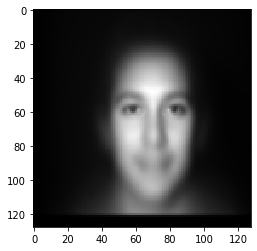

```python
#========Your code here ======
mean_image = np.zeros((IMAGE_SIZE,IMAGE_SIZE))
for i in range(0,len(image_collection)):
    for j in range(0,len(image_collection[0])):
        mean_image[i][j] = np.mean(image_collection[i][j])

# Centering the image_collection using the computed mean image
for i in range(0,len(image_collection)):
    for j in range(0,len(image_collection[0])):
        for k in range(0,len(image_collection[0][0])):
            image_collection[i][j][k] = image_collection[i][j][k] - mean_image[i][j]
#==============================
# Displaying the mean image in grayscale
imgplot = plt.imshow(mean_image,cmap='gray')
```

# Problem 2

Perform PCA on the images using sklearn. Plot the total percentage of variance explained versus number of components. Finally plot the singular values when number of components is 500. Justify the plots.

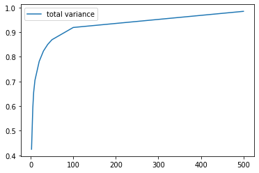

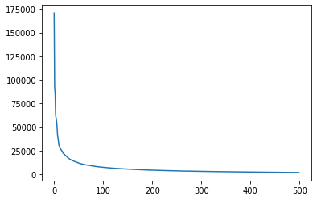

```python
num_comp = [2,5,7,10,20,30,40,50,100,500]
from sklearn.decomposition import PCA
#========Your code here ======
# Preprocess image using method proposed by Aaron Logan in @477
images_centered_flattened = np.transpose(np.reshape(image_collection, (IMAGE_SIZE**2, image_collection.shape[2])))
singular_values = []
total_variance_explained = []
# Iterate over components for PCA
for comp in num_comp:
    pca = PCA(n_components=comp)
    pca.fit(images_centered_flattened)
    if comp == 500:
        singular_values = pca.singular_values_
    total_variance_explained.append(sum(pca.explained_variance_ratio_))
#==============================
plt.figure(1)
plt.plot(num_comp,total_variance_explained,label='total variance')
plt.legend()
plt.show()
plt.figure(2)
plt.plot(range(500),singular_values)
plt.show()
```

### Explanation for Problem 2

For the total percentage variance explained, as we increase the number of components, the total variance explained increased from around 40% to close to 100% at 500 components in PCA. This is expected because as we increase the number of components used, the sum of the percentage variance explained by each of the components shall eventually reach 100%. This implies that all of the variance will eventually be explained by a large number of components.

For singular value plot, as we increase the index of the component (500 components in total), the singular value drops very quickly from 175,000 to almost 0. This is expected as the lower index of the components with larger singular values account for a large percent of the variability.

# Problem 3

Display the first 5 principal components as images in gray scale using matplotlib. Explain your observations.

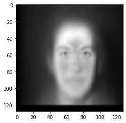

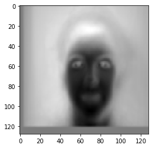

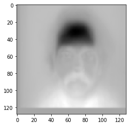

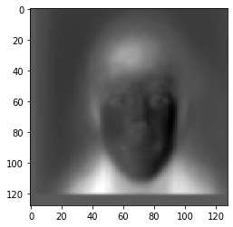

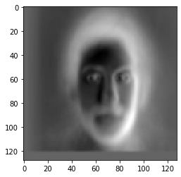

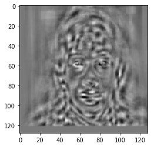

```python
#========Your code here ======
plt.figure(1)
plt.imshow(pca.components_[0].reshape((IMAGE_SIZE,IMAGE_SIZE)),cmap='gray')
plt.figure(2)
plt.imshow(pca.components_[1].reshape((IMAGE_SIZE,IMAGE_SIZE)),cmap='gray')
plt.figure(3)
plt.imshow(pca.components_[2].reshape((IMAGE_SIZE,IMAGE_SIZE)),cmap='gray')
plt.figure(4)
plt.imshow(pca.components_[3].reshape((IMAGE_SIZE,IMAGE_SIZE)),cmap='gray')
plt.figure(5)
plt.imshow(pca.components_[4].reshape((IMAGE_SIZE,IMAGE_SIZE)),cmap='gray')
plt.figure(6)
plt.imshow(pca.components_[400].reshape((IMAGE_SIZE,IMAGE_SIZE)),cmap='gray')
#==============================
```

### Explanation for Problem 3

In each of the components, we can clearly see an unique outline of the face, extenuating various features of the person's face, such as the forehead, moustache, eyes, and etc. These features/outlines are the strongest and the most clearly defined out of the 500 components. In comparing these components with components of higher indices, we can see that these first five components are much stronger and clearly defined than the later components. The 400th components is shown for comparison. It is much less well defined and is more distorted.

# K-means for Image Quantization

In this part of the assignment you will implement your own k-means algorithm and use it for image quantization.

As we know image consists of pixels. For standard colored image, each pixel is a 3D vector where each component is an integer from 0 to 255 which represents the intensity of red, green and blue light.

Sometimes we may want to reduce the number of colors in an image. One naive way is to simply reduce the quantization bits of pixels: instead of using 0-255 which could be written as 8 bit binary, we simply reduce the number of bits (for example, using 4 bits means that we use integers 0-15 instead). However, this method may not capture the original color of the image as you will see in an example.

K-means provides a better alternative: we treat each pixel as a vector, and try to find $k$ colors (centroids) that best represent the colors in the image.

The following code reads an image and converts it to a set of vectors. You may need to install OpenCV for python. To install, simply run `pip install opencv-python` in your terminal/Anaconda prompt

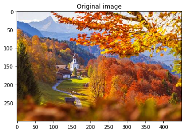

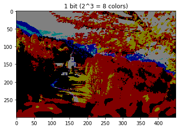

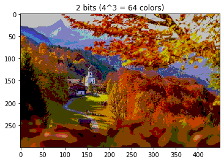

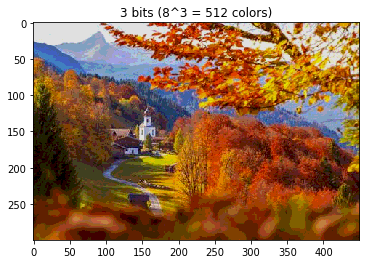

```python
import matplotlib.pyplot as plt
import cv2

img = cv2.imread("image.jpg")
img = cv2.cvtColor(img, cv2.COLOR_BGR2RGB)

# Some useful parameters
height = img.shape[0]
width = img.shape[1]
n = height * width

# Reshaping the image into vectors.
vec_img = img.reshape((-1, 3))
vec_img = np.float32(vec_img)

# Display original and quantized images.
plt.figure()
plt.title("Original image")
plt.imshow(img)

plt.figure()
quantized_img = np.uint8(np.float32(img)/128)*128
plt.title("1 bit (2^3 = 8 colors)")
plt.imshow(quantized_img)

quantized_img = np.uint8(np.float32(img)/64)*64
plt.figure()
plt.title("2 bits (4^3 = 64 colors)")
plt.imshow(quantized_img)

quantized_img = np.uint8(np.float32(img)/32)*32
plt.figure()
plt.title("3 bits (8^3 = 512 colors)")
plt.imshow(quantized_img)
```

# Problem 4: Implement your own k-means algorithm

Now you will implement your own k-means algorithm. Random initialization of centroids is sufficient for this assignment. You are NOT allowed to use any k-means imlementations in any existing libraries, including but not limited to those in OpenCV and Scikit-learn. Your algorithm takes the following input:

$K$ - the number of clusters/centroids

$vec$ - the set of vectors ($n\times d$ array where $n$ is the number of vectors and $d$ is the dimension of each vector)

$eps$ - algorithm should stop when the average distance change of centroids is smaller than this number. More specifically, let $c_k^{(i)}$ be the $k$'th centroid in iteration $i$, the algorithm should stop when: $$ \frac{1}{K}\sum_{k=1}^K \|c_k^{(i)}-c_k^{(i-1)}\|^2<eps $$ $max\_iter$ - maximum number of iterations

Your algorithm should stop when either of the two criteria (change of centroids less than $eps$, or maximum iteration) is satisfied.

It should return two values:

$centroids$ - the centroids for each cluster arranged in a $K\times d$ array

$labels$ - the labels of each vector, an $n$ dimensional 1-d array. Each label should be an integer from $\{0, ..., K-1\}$

```python
from random import *
def k_means(vec, K, eps, max_iter):
    #============ Your code here ====================
    # Initialization
    def euclidean(a,b):
        dist = (a-b)**2
        dist = np.sum(dist)
        return np.sqrt(dist)
    n = vec.shape[0]
    d = vec.shape[1]
    centroids = np.zeros((K, d))
    # random sample k centroids
    selected = []
    for i in range(0,K):
        randindex = randint(0,len(vec))
        while (randindex in selected):
            randindex = randint(0,len(vec))
        selected.append(randindex)
    for i in range(0,K):
        centroids[i] = vec[selected[i]]
    labels = np.zeros(n).astype(int)
    count = 0
    cbefore = centroids.copy()
    cafter = centroids.copy()
    # Start update
    while (count < max_iter):
        cbefore = centroids.copy()
        # iterate over n examples in vec
        for i in range(0,len(vec)):
            minindex = -1
            # find minimum distance between xi and centroid cj
            mindist = float('inf')
            for j in range(0,len(centroids)):
                if (euclidean(vec[i],centroids[j]) < mindist):
                    mindist = euclidean(vec[i],centroids[j])
                    minindex = j
            labels[i] = minindex
        for j in range(0,K):
            ele = np.where(labels==j)[0]
            n_ele = len(ele)
            summation = np.zeros((d,))
            for i in range(0,n_ele):
                summation+= vec[ele[i]]
            centroids[j] = 1/n_ele*summation
        cafter = centroids.copy()
        diff = 0
        for i in range(0,K):
            diff+= euclidean(cbefore[i],cafter[i])**2
        diff = 1/K*diff
        if (diff < eps):
            return centroids, labels
        count+=1
    #=============== End code =====================
    return centroids, labels
```

Now comes the fun part: display the quantized image for $K=4, 8, 16, 32$. You will observe that k-means quantization achieves far better results than the naive quantization strategy with much less number of colors.

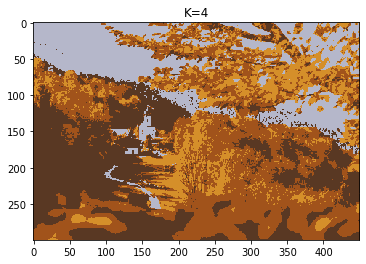

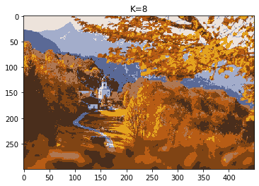

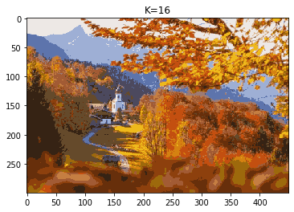

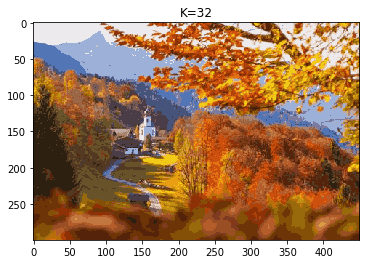

```python
K = [4, 8, 16, 32]
eps = 1e-6
max_iter = 10000

for k in K:
    plt.figure()
    centroids, labels = k_means(vec_img, k, eps, max_iter)
    compressed_vec = centroids[labels, :]
    compressed_img = compressed_vec.reshape(img.shape)
    compressed_img = np.uint8(compressed_img)
    plt.imshow(compressed_img)
    plt.title("K=" + str(k) )
```

# Problem 5: Try with your own image (this part is not graded)

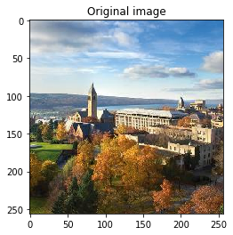

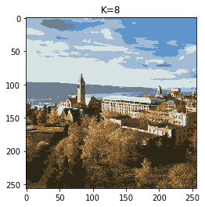

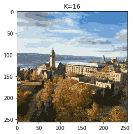

```python
# Demonstrate with K = 8, 16 and eps = 1e-6
K = [8,16]
eps = 1e-6
max_iter = 10000

img = cv2.imread("cornell.jpg")
img = cv2.cvtColor(img, cv2.COLOR_BGR2RGB)
# Some useful parameters
height = img.shape[0]
width = img.shape[1]
n = height * width
# Reshaping the image into vectors.
vec_img = img.reshape((-1, 3))
vec_img = np.float32(vec_img)
# Display original and quantized images.
plt.figure()
plt.title("Original image")
plt.imshow(img)
for k in K:
    plt.figure()
    centroids, labels = k_means(vec_img, k, eps, max_iter)
    compressed_vec = centroids[labels, :]
    compressed_img = compressed_vec.reshape(img.shape)
    compressed_img = np.uint8(compressed_img)
    plt.imshow(compressed_img)
    plt.title("K=" + str(k) )
```